# Ezra Cohen lab 6

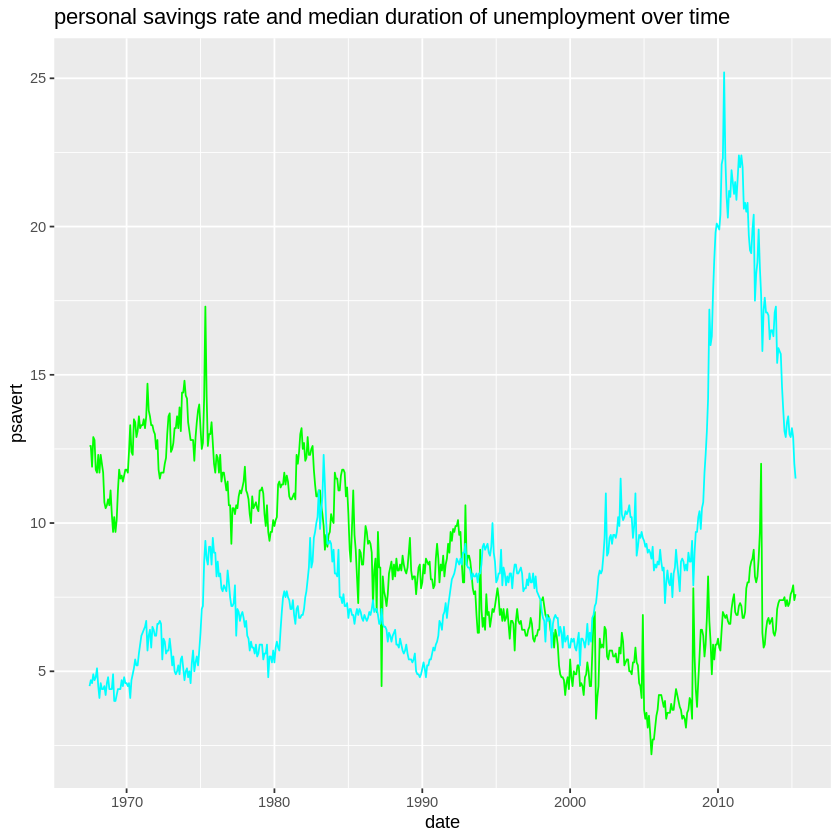

```r
myPlot <- myPlot + ggtitle("personal savings rate and median duration of unemployment over time")
#changes the title to be more fitting to the new graph
myPlot
```

task 9

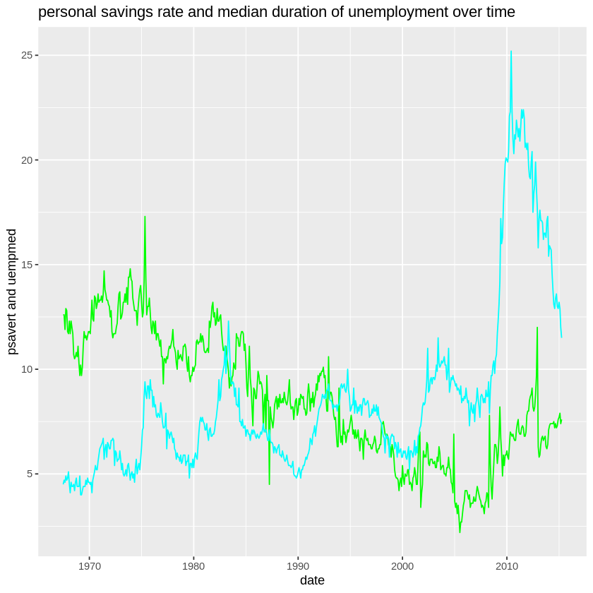

```r
myPlot <- myPlot + ylab("psavert and uempmed")
#changes the name of the y axis to be more fitting to the new graph
myPlot
```

task 10

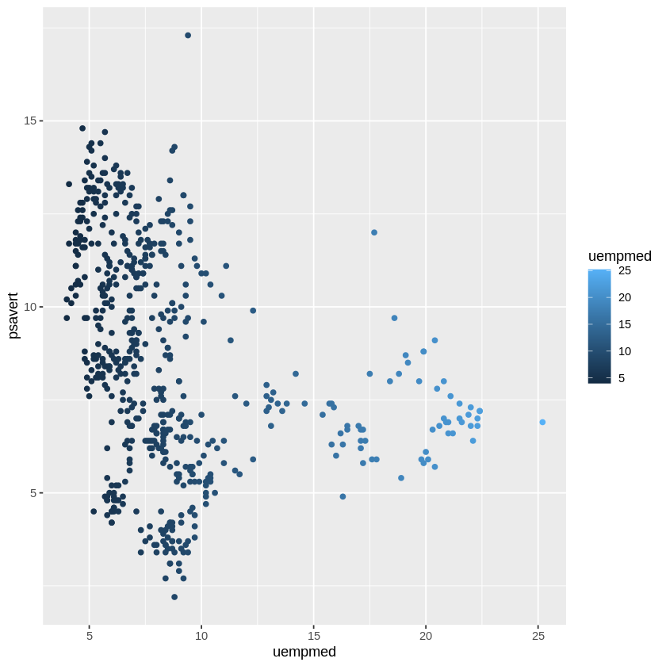

```r
myPlot2 <- ggplot(economics, aes(x=uempmed,y=psavert))
#makes axis of plot
myPlot2 <- myPlot2 + geom_point(aes(color=uempmed))
#makes scaterplot with a color gradient based on uempmed
myPlot2
```

task 11

The personal savings rate of people who are unemployed for very little time is all over the place but it is relatively high for the most part, the longer people are unemployed though the lower the personal savings rate goes, add around 10 weeks the personal savings rate is just about the lowest that it goes, and by the really late stages there are much fewer points which indicates there are very few people who are unemployed for that long and the people who are unemployed for that long likely have someone supporting them a bit which would explain why they have any personal savings at all And also why those personal savings are actually a bit higher than people who were unemployed for 5 to 10 weeks less, because those people haven't had enough time to find someone to support them yet

task 12